# Re-Analysis of a published RNAseq data

Emmanuel Kagning Tsinda

December 12, 2019

# **OUTLINE OF THIS REPORT**

1-Introduction

2-Quality control of data

3-Differential expression analysis usig DEseq

4-Conclusion

# Introduction

I would like to re-analyze the RNAseq data published in this paper https://www.nature.com/articles/s41467-019-10197-x. Therefore, my task here is to determine whether a fold change of gene expression is different between two types of human stem cells derived from dental pulp (DPSC) and bone marrow (BMSC). In this report created with Rmarkdown, i would like to describe the workflow and tools that i used as well as the results obtained. I also make some interpretation and comments of genes’ differential expression analysis between BMSC compared to DPSC.

**a. Retrieve the data :** At first, I downloaded all six fastq files related to this project from [Gene expression Omnibus link provided earlier](https://www.ncbi.nlm.nih.gov/geo/query/acc.cgi?acc=GSE105145) using SRA tools and CLC genomics v10 download tool. the hg38 version of the human genome, including various annotations were also downloaded from Ensembl website.

**b. Quality control :** Quality control of raw reads was done using fastQC, a snapshot of the results can be seen [here](https://drive.google.com/file/d/1ih_uSUvNSvylktIo8zwHagzOCIWu0-vs/view?usp=sharing). Based on that QC report, I decided to trim the first 15 nt. I also filtered reads with PHRED score <20 and reads below 75 nucleotides of length.

**c. Reads mapping :** Mapping of the quality trimmed reads to the hg38 version of human genome was done.Reads’s alignement for each sample was done using CLC genomics v10 read mapper. Its mapping algorithm is very similar, but faster than [Bowtie short reads aligner](http://bowtie-bio.sourceforge.net/news.shtml). Alignement workflow can be seen [here](https://drive.google.com/file/d/1MPCVAqtmUyZIVucMsGYW38a42OmKV-n1/view?usp=sharing). The NGS reads mapping to human reference genome was successfully done because more than 90% of reads were correctly mapped; as shown in the following [mapping report](https://drive.google.com/file/d/1_aDoweUvHCY5yfbC4ig1dvpb6Ilx_rWT/view?usp=sharing). A file containing total read counts (generated by CLC genomics workbench V10) was imported into R for downstream statistical analyses. All imput data used below were provided for reproducibility.

**d. Statistical analyses :** Negative binomial model was fitted to each normalized count for each sample and Wald test was performed to estimate the fold change of total RNA read counts in BM-MSCs compared to DP-MSCs. The statistical methods used here have been implemented in [DESeq R package](https://genomebiology.biomedcentral.com/articles/10.1186/s13059-014-0550-8). The Benjamini & Hochberg p-value adjustment methodology was used to correct for multiple testing. I also made several plots to inspect the data before and after differential expression analyses. DPSC samples were used as reference in our comparisons.

## 1-Load packages and data and metadata (phenotype data)

```r
library(DESeq2)
library(dplyr)
library(reshape2)
library(ggplot2)
library (pander)
library(pheatmap)
library(RColorBrewer)
library(VennDiagram)
```

Let us import the RNAseq count data

```r
setwd("C:/Users/Virology Tohoku/Documents/jobs/Rhoto/Internship assignement/RNAseq_data")
count_data <- read.table(file = "total_counts.txt", header = T, sep = "\t")
head(count_data)
```

```
##    Gene_Name SRR6189571 SRR6189572 SRR6189573 SRR6189574 SRR6189575 SRR6189576
## 1    DDX11L1          0          0          3          0          0          0
## 2     WASH7P        225        183        219        440        507        586
## 3 MIR1302-10          0          0          0          0          0          0
## 4    FAM138A          0          0          0          0          0          0
## 5     OR4G4P          0          0          0          0          0          0
## 6    OR4G11P          0          0          0          0          0          0
```

```r
str(count_data)
```

```
## 'data.frame':    57773 obs. of  7 variables:
##  $ Gene_Name : Factor w/ 57773 levels "5S_rRNA_1","5S_rRNA_2",..: 13274 55492 22546 14933 26333 26329 26325 38811 38812 9834 ...
##  $ SRR6189571: int  0 225 0 0 0 0 0 19 6 0 ...
##  $ SRR6189572: int  0 183 0 0 0 0 0 42 1 0 ...
##  $ SRR6189573: int  3 219 0 0 0 0 0 9 0 0 ...
##  $ SRR6189574: int  0 440 0 0 0 0 0 24 6 0 ...
##  $ SRR6189575: int  0 507 0 0 0 0 0 20 6 0 ...
##  $ SRR6189576: int  0 586 0 0 0 0 0 13 3 0 ...
```

```r
rownames(count_data) <- count_data$Gene_Name
count_data <- count_data[,2:7]
count_data = count_data[rowMeans(count_data) > 1,] # to filter lowly expressed genes
```

Let us import the metadata

```r
col_data = read.csv(file = "metadatata_assignement.csv")
colnames(col_data)[1]<- "Sample"
colnames(col_data)[7] <- "condition"
head(col_data)
```

```
##       Sample Experiment.Accession Project.Accession Sample.Accession
## 1 SRR6189571           SRX3299601         SRP120476       SRS2610811
## 2 SRR6189572           SRX3299602         SRP120476       SRS2610813
## 3 SRR6189573           SRX3299603         SRP120476       SRS2610834
## 4 SRR6189574           SRX3299604         SRP120476       SRS2610812
## 5 SRR6189575           SRX3299605         SRP120476       SRS2610815
## 6 SRR6189576           SRX3299606         SRP120476       SRS2610814
##   Submission.Accession Description condition
## 1            SRA620993          NA      BMSC
## 2            SRA620993          NA      BMSC
## 3            SRA620993          NA      BMSC
## 4            SRA620993          NA      DPSC
## 5            SRA620993          NA      DPSC
## 6            SRA620993          NA      DPSC
```

## 2-Quality check of sequencing data

There might be multiple technical bias involved in RNAseq experiment such as batch effects, library size, genes length etc. Ideally, it is preferable to minimize bias from the beginning of the experiment because, there is a famous adage in statistics “…garbage in barbage out…”. Our goal here is to control or even minimize those bias during our analyses. Let us make some quality control exploratory plots.

```r
# load the DESeq2 package
dds = DESeqDataSetFromMatrix(countData = count_data,
                             colData = col_data,
                             design = ~ condition) # below I will do PCA based on the cell condition
dds$condition <- relevel(dds$condition, ref="DPSC")# setting DPSC as comparison reference
```

Now let us take a look at the distribution of reads in one sample SRR6189571(BMSC)

### a-Histogram of counts data for one sample

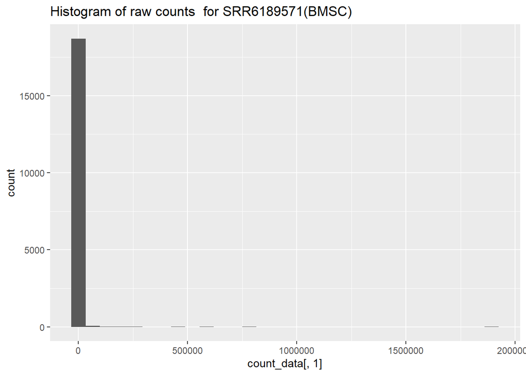

```r
ggplot2::ggplot(count_data, aes(count_data[,1]))+geom_histogram()+ggtitle("Histogram of raw counts  for SRR6189571(BMSC)")
```

```r
# Plotting distribution off counts of the first sample (column 1)
```

### b-Barplot of library sizes

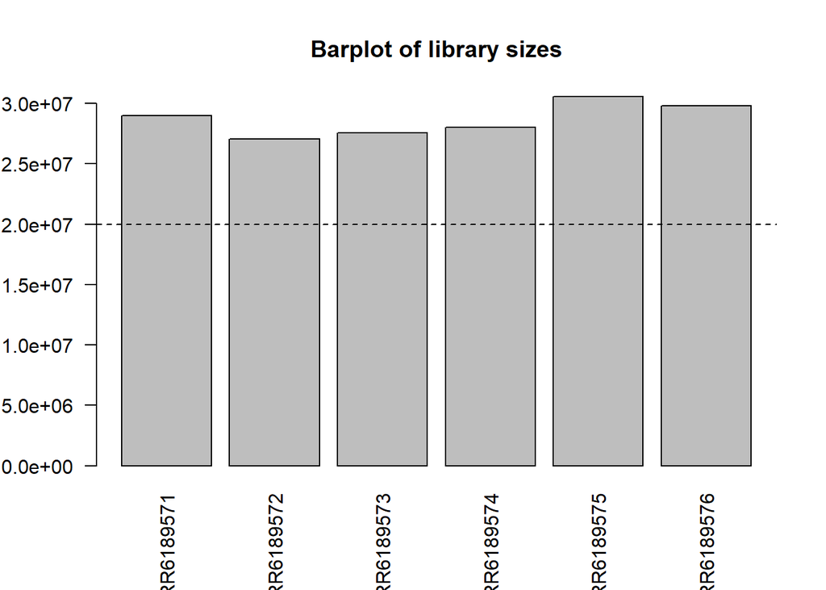

```r
librarySizes <- colSums(count_data)
barplot(librarySizes,
        names=names(librarySizes),
        las=2,
        main="Barplot of library sizes")
abline(h=20e6, lty=2)
```

We can see that the sequencing depth of all samples were almost similar–> that seems OK.

### c-Density plot raw counts

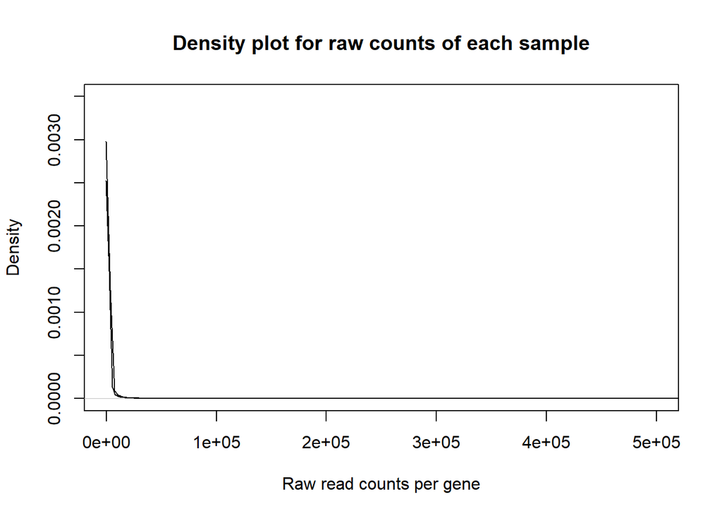

```r
#Density plots of log-intensity distribution of each library can be shown on a single graph for a better comparison between libraries and for identification of libraries with weird distribution.
d <- density(count_data[,1])
plot(d, xlim=c(0,500000), ylim=c(0,0.0035), main="Density plot for raw counts of each sample",
     xlab="Raw read counts per gene", ylab="Density")

for (s in 2:length(samples)){
  d <- density(count_data[,s])
  lines(d)
}
```

I expect the lines of this plot (corresponding to each samples) to be superposed, indicating a similarity between the samples.

### d-Scatterplot of log2 gene counts between two samples

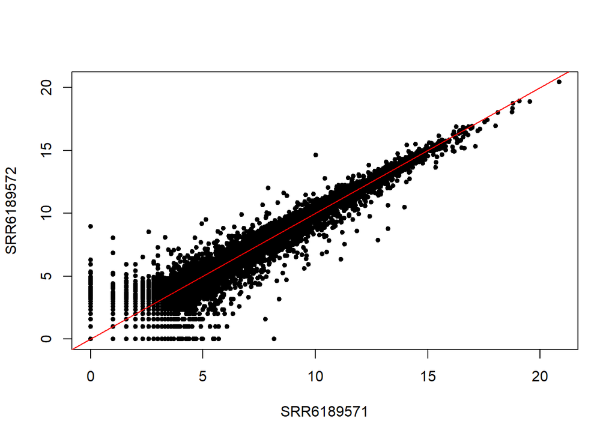

```
## integer(0)
```

```r
# We should also investigate any systematic bias in the sequencing data, such as whether one sample has been sequenced more deeply than others.
pseudoCount = log2(count_data + 1) # log-transform to make numbers on scale (+1 to avoid zeroes)
plot(pseudoCount[,1], pseudoCount[,2], pch = 20,
     xlab = "SRR6189571", ylab = "SRR6189572") + # pch specifies the type of symbols. Filled dots in this case.
  abline(0,1, col = "red") # make a diagonal line
```

For these two samples to be comparable, we would expect the correlation between the two samples to be a high as possible. Based on the plot above, we can see that there is a high variance for lowly expressed genes. I need to use a normalization method which is robust enough.

### e-Boxplot of raw counts

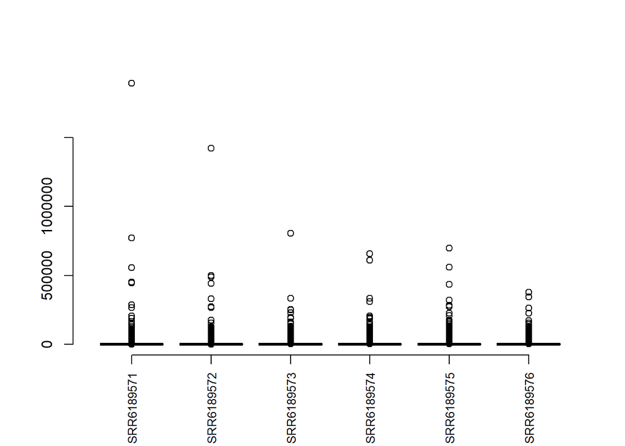

```r
boxplot(count_data, axes=FALSE)# raw counts are not normally distributed
axis(2)
axis(1,at=c(1:length(colnames(count_data))),labels=colnames(count_data),las=2,cex.axis=0.8)
```

This boxplot shows that raw counts of genes for each samples contain outliers. In order to compare gene expression, we need make all samples **comparable**. We need to normalize this data.

### f-Boxplot of log2 normalized counts

```r
# We can plot the normalized counts (compare with the previous box plot):
dds = estimateSizeFactors(dds)
norm_counts = counts(dds, normalized = TRUE) # Extract the normalized counts
head(norm_counts)
```

```
##               SRR6189571 SRR6189572 SRR6189573 SRR6189574 SRR6189575 SRR6189576
## WASH7P        272.272989 213.747188 214.956986 401.419782   458.2773 499.470448
## RP11-34P13.7   22.991941  49.056732   8.833849  21.895624    18.0780  11.080402
## RP11-34P13.8    7.260613   1.168017   0.000000   5.473906     5.4234   2.557016
## AL627309.1     65.345517  60.736906  64.781557  62.037603    27.1170  17.046773
## RP11-34P13.13  43.563678  24.528366  44.169244 137.759971   147.3357  52.844996
## AP006222.2     37.513167  59.568889  61.836941  14.597083    11.7507  12.785080
```

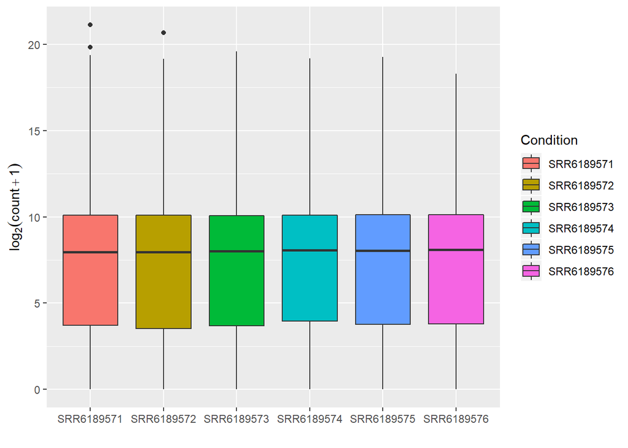

```r
pseudoCount = log2(norm_counts + 1) # convert to log-scale for visualization
df = melt(pseudoCount) # transpose the matrix
df = data.frame(df, Condition = substr(df$Var2, 1, 10))
ggplot(df, aes(x = df$Var2, y = value, fill = Condition)) + geom_boxplot() + xlab("") +
  ylab(expression(log[2](count + 1)))
```

```r
# hist(pseudoCount[,1]) # the distribution now looks better, compared to the previous histogram i made above
```

Log2 normalisation has improved the between of samples comparison. Therefore, I will use normalized counts during the differential expression analysis below. Before that, let us select a suitable normalisation method.

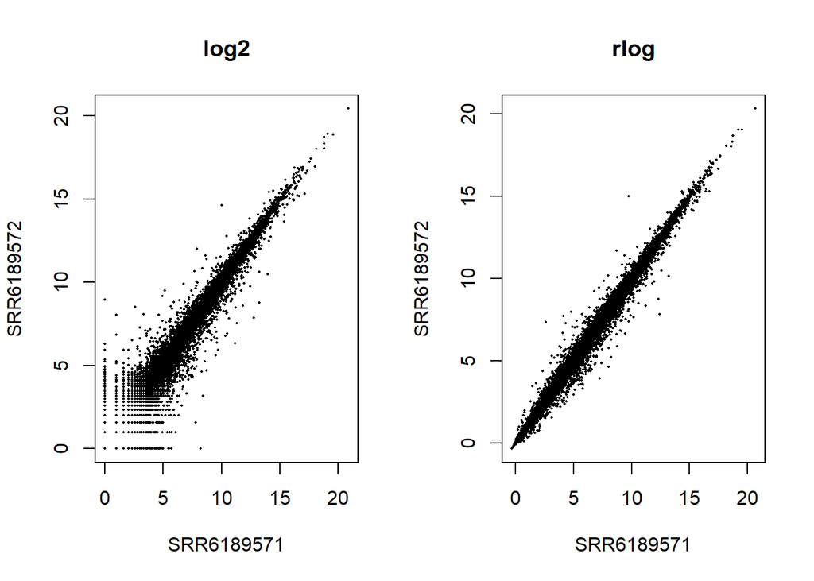

```r
#It is common to use the log2 transformation to normalize the reads count. Let us compare the log2 vs the rlog transformation implemented in DEseq:
rld = rlogTransformation(dds) # the rlog normalization also stabilizes the variance.
par( mfrow = c( 1, 2 ) )
plot(log2( 1 + counts(dds)[ , 1:2] ),
     pch=16, cex=0.3, main = "log2")
plot(assay(rld)[ , 1:2], # The assay function returns the count values of rld in a matrix
     pch=16, cex=0.3, main = "rlog")
```

I will use rlog transformed count data to make plots below, because it seems better (reduced noise)

### g- Clustering of samples

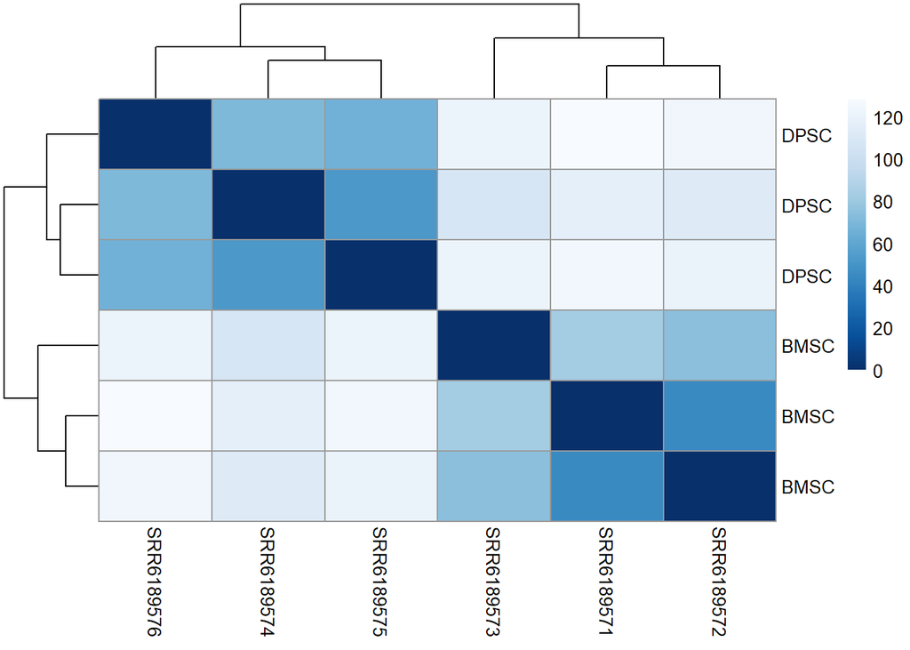

```r
# Heatmap and clustering to represent the sample-to-sample distances
distsRL <- dist(t(assay(rld))) # Calculates distances using normalised counts
mat <- as.matrix(distsRL) # convert to matrix
rownames(mat) <- colnames(mat) <- with(colData(dds), paste(condition)) # set labels of the matrix
colnames(mat) <- with(colData(dds), paste(Sample))
# colnames(mat) = NULL # remove column names
colors <- colorRampPalette( rev(brewer.pal(9, "Blues")) )(255) # set colors
pheatmap(mat,
         clustering_distance_rows=distsRL,
         clustering_distance_cols=distsRL,
         col=colors) # draw the heatmap
```

All DPSC and BMSC form separate clusters (which is what I expect).There are no apparent outlying samples. This observation is confirmed by the PCA drawn below.

### h-Principal component analysis (PCA)

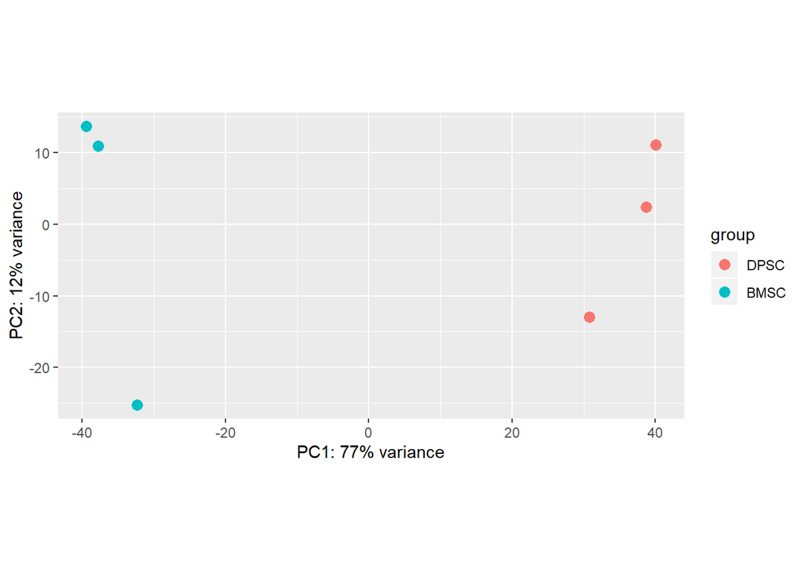

```r
#Principal component analysis is a statistical procedure that uses an orthogonal transformation to convert a set of observations of possibly correlated variables into a set of values of linearly uncorrelated variables called principal components. This transformation is defined in such a way that the first principal component has the largest possible variance, and each succeeding component in turn has the highest variance possible under the constraint that it is orthogonal to the preceding components. The resulting vectors are an uncorrelated orthogonal basis set (https://en.wikipedia.org/wiki/Principal_component_analysis).

plotPCA(rld, intgroup=c("condition"))
```

PCA is often used to visualize distance and relatedness between samples. Plotting 1st and 2nd principal components (here representing 89% of total variance) shows separates DPSC samples from BMSC samples. I could have investigated other possible batch effects, but the authors of the paper did not provide other experimental data such as RNA integrity number, sequencing lane number etc. lane effect < flow cell effect < library preparation effect < biological effect (page 8[http://www.nathalievialaneix.eu/doc/pdf/tutorial-rnaseq.pdf]) Note that the total variance explained by PC1&PC2 of this PCA is higher than the total variance explained by PC1&PC2 in the paper of Shen WC et al, nat comm, 2019.

### I-MA plot before differential expression

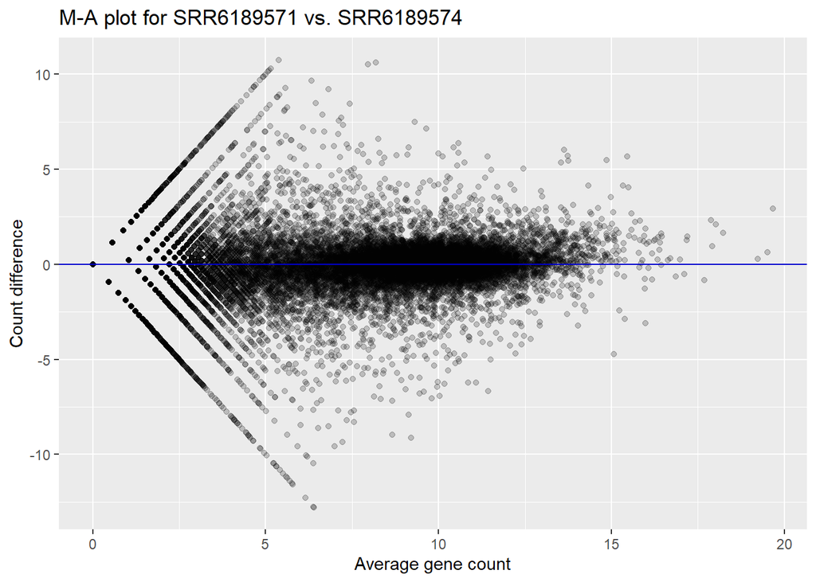

```r
#An MA plot is an application of a Bland-Altman plot for visual representation of genomic data. The plot visualizes the differences between measurements taken in two samples, by transforming the data onto M and A scales, then plotting these values. In many microarray/RNAseq gene expression experiments, an underlying assumption is that most of the genes would not see any change in their expression; therefore, the majority of the points on the y-axis (M) would be located at 0, since Log(1) is 0. If this is not the case, then a normalization method such as LOESS should be applied to the data before statistical analysis (https://en.wikipedia.org/wiki/MA_plot).
x = pseudoCount[, 1] # extract counrs of the 1st column
y = pseudoCount[, 4] # extract counts of the 4th column
M = x - y # M-values (differences between samples)
A = (x + y)/2 # Average values
df = data.frame(A, M)
ggplot(df, aes(x = A, y = M)) + geom_point(size = 1.5, alpha = 1/5) +
  geom_hline(aes(yintercept = 0), color = "blue3") +
  xlab("Average gene count") +
  ylab("Count difference") +
  ggtitle("M-A plot for SRR6189571 vs. SRR6189574")
```

Thiis is a plot of the difference in expression against the mean expression level. There is still a high variance for lowly expressed genes, because we used the log2 transformation of counts to make this plot. as shown earlier, regularised logarithmic transformation would be better.

```r
# Normalization is will be done by DESeq2.
#the command below will estimate a size factor (scaling factor). All the genes in a sample will be multiplied with by factor during normalization.
dds = estimateSizeFactors(dds)
sizeFactors(dds)
```

```
## SRR6189571 SRR6189572 SRR6189573 SRR6189574 SRR6189575 SRR6189576
##  0.8263765  0.8561516  1.0188085  1.0961094  1.1063170  1.1732426
```

## 3-Differential expression analysis usig DEseq

The null hypothesis here is that the logarithmic fold change between BMSC and DPSC for a genes expression is exactly zero, i.e., that the gene’s expression level (at all) is not affected by the phenotype of mesenchymal stem cell.

```r
dds = DESeq(dds)# DESeq runs several functions including mormalization, fitting of negative binomial model, Wald test and correction p-value.
# DEseq will fits the relation between the mean and variance.
# plotDispEsts(dds, main="Dispersion plot")
# The black points are the dispersion estimates for each gene as obtained by considering the information from each gene separately.Therefore, the red trend line is fitted, which shows the dispersions dependence on the mean, and then shrink each gene's estimate towards the red line to obtain the final estimates (blue points) that are then used in the hypothesis test(Bernd Klaus[ et al,2016).
```

## a-Building the results table

```r
res <- results(dds, alpha=0.05) # to see differentially expressed genes with adjusted p value above 0.05 as done in the paper
#mcols(res, use.names=TRUE)
#summary(res)
#head(res)
```

## b-Descriptive plots after testing for differential expression

Let us do a some plots to make sure everything looks good and that I have not t made a mistake in the analysis.

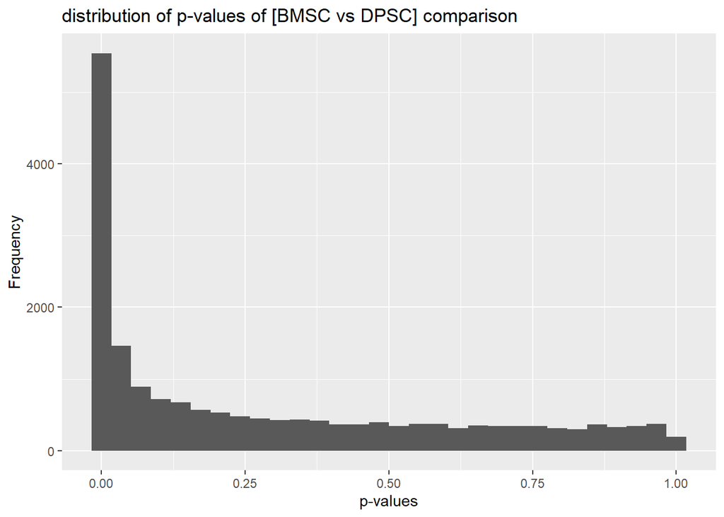

```r
## Examine plot of p-values
ggplot(as.data.frame(res), aes(pvalue) ) + geom_histogram() +
  labs(y="Frequency", x = "p-values")+ggtitle("distribution of p-values of [BMSC vs DPSC] comparison")
```

It looks OK ! it is what we expect.

### b1-MA plot after differential expression

```r
#There might be a lot of noise associated with log2 fold changes from low count genes. DESeq2 can produce shrunken log2 fold changes that are more precise.
# It looks at the largest fold changes that are not due to low counts and uses these to inform a prior distribution. So the large fold changes from genes with lots of statistical information are not shrunk, while the imprecise fold changes are shrunk .

resultsNames(dds)
```

```
## [1] "Intercept"              "condition_BMSC_vs_DPSC"
```

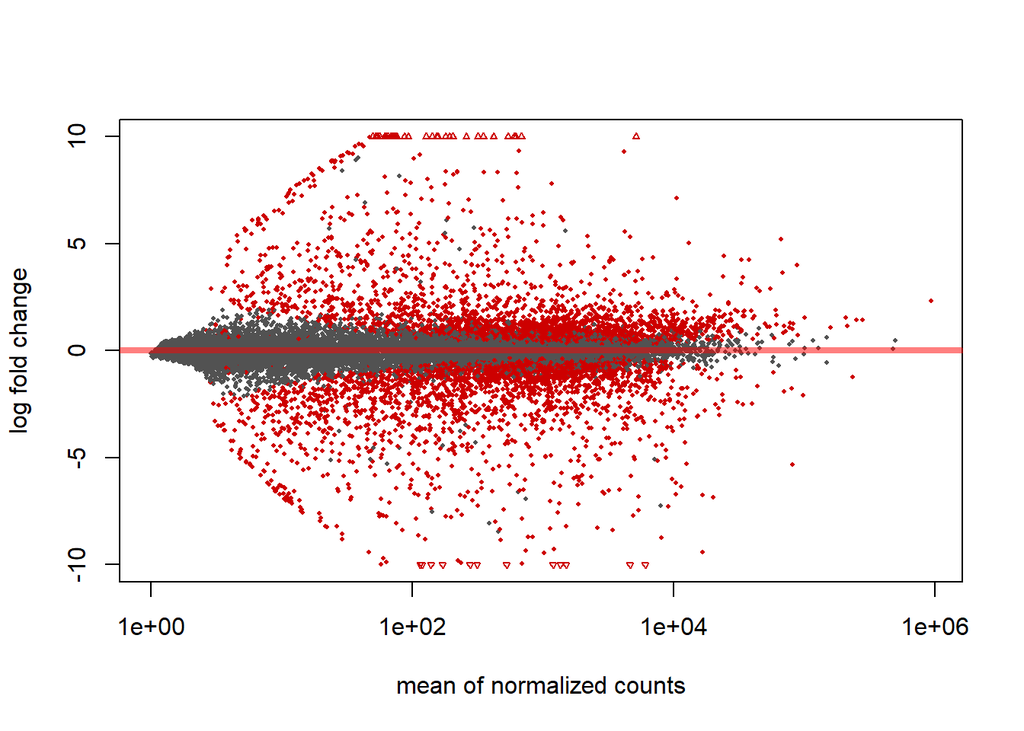

```r
res = lfcShrink(dds, coef="condition_BMSC_vs_DPSC", type = "apeglm")
plotMA(res, ylim=c(-10,10), alpha=0.05)
```

```r
# Red points have adjusted pvalue < 0.05.
```

This plot demonstrates that almost all genes with a large average normalized count contain sufficient information to yield a significant call. Now let us plot the results as fold-change (log2) versus unadjusted p-value (-Log10) in a volcano plot plot.

### b2-Volcano plot

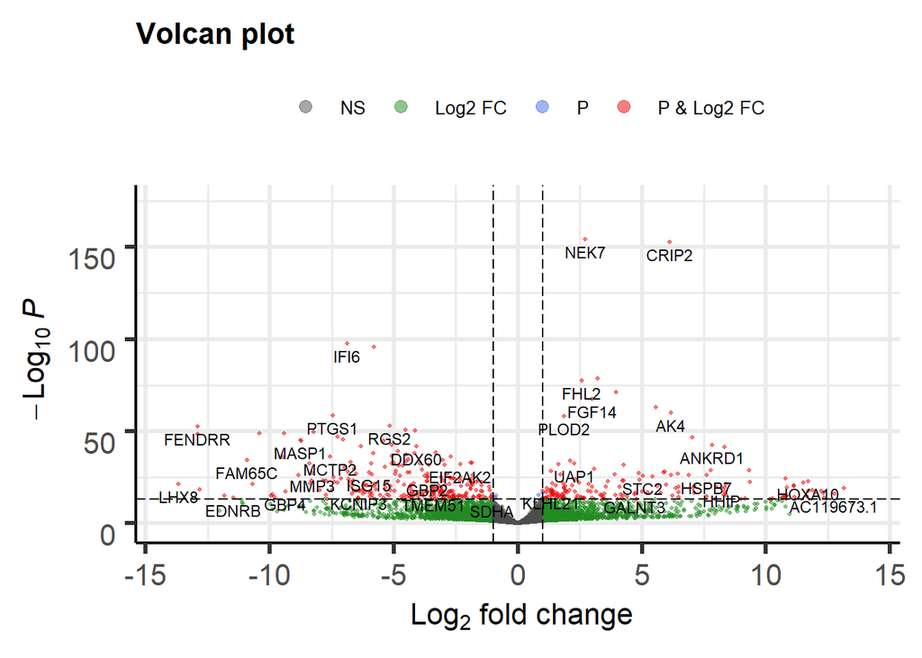

```r
library(EnhancedVolcano)
EnhancedVolcano(res, lab = rownames(res), x = 'log2FoldChange', y = 'pvalue',
                xlab = bquote(~Log[2]~ "fold change"), ylab = bquote(~-Log[10]~italic(P)),
                col = c("grey30", "forestgreen", "royalblue", "red2"),
                title = "Volcan plot",
                 xlim = c(-14, 14), ylim=c(-2,175), FCcutoff=1, pCutoff = 10e-14)
```

### b3-Heatmap of differentially expressed genes

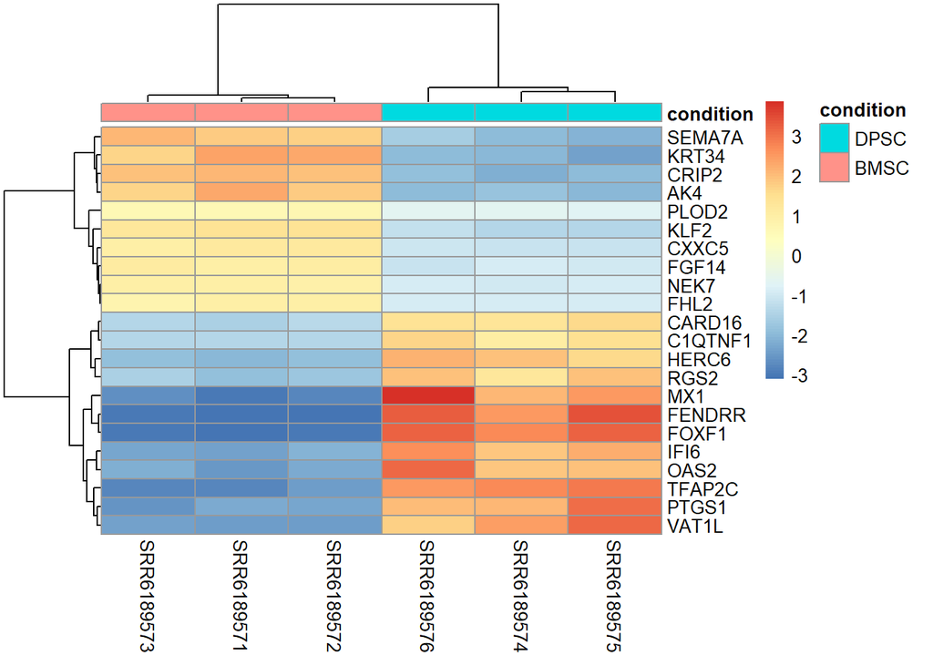

```r
library("pheatmap")
mat = assay(rld)[ head(order(res$padj),22), ] # select the top 22 genes with the lowest padj
mat = mat - rowMeans(mat) # Subtract the row means from each value
# Optional, but to make the plot nicer:
df = as.data.frame(colData(rld)[,c("condition")]) # Create a dataframe with a column of the conditions
colnames(df) = "condition" # Rename the column header
rownames(df) = colnames(mat) # add rownames
# and plot the actual heatmap
pheatmap(mat, annotation_col=df)
```

This heatmap displays top 22 genes which have a significanlly different expression level between DPSC and BMSC.

```r
assay(rld)["VAT1L",] # to look at the values of a one gene, VAT1L
```

```
## SRR6189571 SRR6189572 SRR6189573 SRR6189574 SRR6189575 SRR6189576
##   5.705716   5.688868   5.795455  10.623189  11.266052   9.864067
```

## c-Filtering the results

```r
down <- res[res$log2FoldChange<=-1, ] # to see the number of downregulated genes
dim(down)
```

```
## [1] 1981    5
```

```r
# there are 1981 downregulated genes in BMSC compared to DPSC
# in Shen WC et al, they found 1705 downregulated genes.
up <- res[res$log2FoldChange>=1,]
dim(up)
```

```
## [1] 1622    5
```

```r
# there are 1622 up-regulated genes
# in Shen WC et al, they found 1359 up-regulated genes.
no <- res[res$log2FoldChange>-1 & res$log2FoldChange <1,]
dim(no) # majority of genes or 80% (15193/18796) are uniformly expressed in both groups
```

```
## [1] 15193     5
```

```r
#Which gene has the lowest fold change in BMSC compared to DPSC ?
head(res[order(res$log2FoldChange), ], 10) # sort fold change by ascending order
```

```
## log2 fold change (MAP): condition BMSC vs DPSC
## Wald test p-value: condition BMSC vs DPSC
## DataFrame with 10 rows and 5 columns
##                       baseMean    log2FoldChange             lfcSE
##                      <numeric>         <numeric>         <numeric>
## LHX8          525.893577373401  -13.685669083964  3.37788741222815
## FENDRR        6060.87755159769 -12.9159691308536 0.830388430559438
## FOXF1         4636.29252423413 -12.9153242354853 0.859457853415703
## RP11-510C10.3 312.683735263896 -12.8331474189773  3.29748852021314
## CBLN2         275.586166666636 -12.0325990139479  3.81772965124142
## AC018470.4    170.078221432687 -11.8187138069649  3.21296344481384
## EDNRB         138.137257920657  -11.464879883415  3.18443609473275
## SP9           114.339656327915 -11.1450571458681  3.15703940245217
## ABCB1         118.618883214974 -11.1255974174331  3.22790131717568
## CTD-2541J13.2 118.418593282293 -11.0992782785827  3.25219513816677
##                             pvalue                 padj
##                          <numeric>            <numeric>
## LHX8           8.5216320741305e-22 1.01384390244115e-19
## FENDRR        4.29899489474346e-53 5.40690729333164e-50
## FOXF1         4.02045928556108e-49 3.53961235500798e-46
## RP11-510C10.3 7.21346609317254e-19 6.35073554842911e-17
## CBLN2          1.5173333645376e-07 2.30122359024789e-06
## AC018470.4    1.49672144650305e-15 8.33995925000812e-14
## EDNRB         2.20010123820699e-14  1.0330502027293e-12
## SP9           1.60364890466271e-13  6.6912440552846e-12
## ABCB1         1.10150429026948e-11 3.57846633635884e-10
## CTD-2541J13.2 3.54586220375536e-11 1.07647485661594e-09
```

LHX8 is the strongest down-regulated gene in BMSC (and up-regulated in DPSC).

### Plot of the gene with down-regulated in BMSC

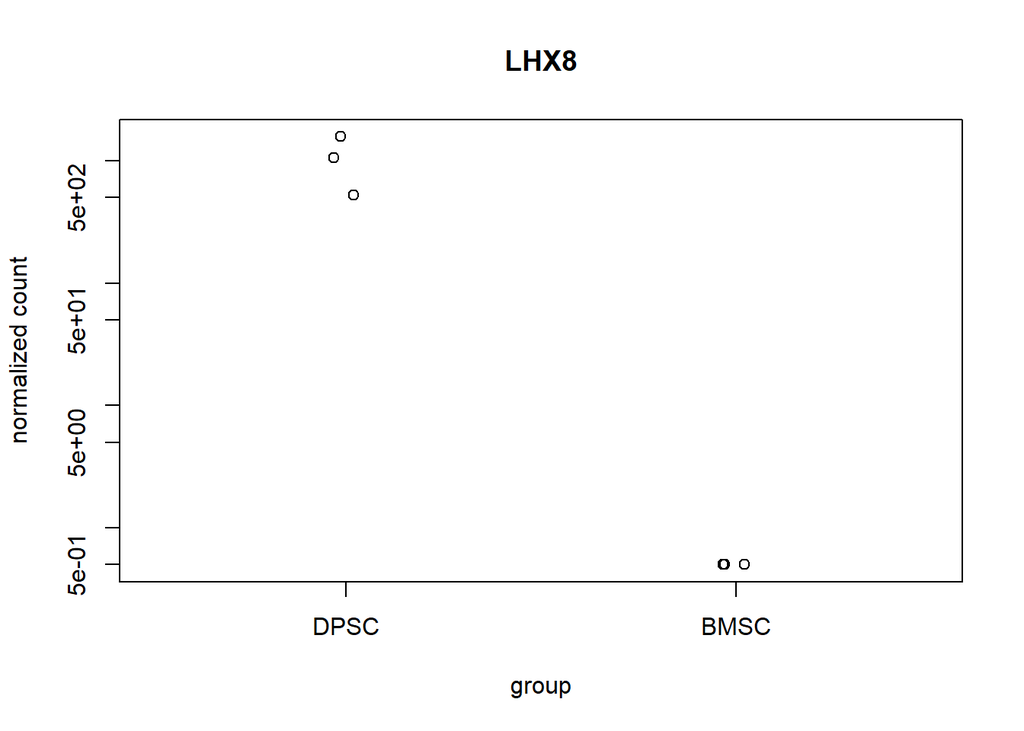

```r
# Plot the top down-regulated gene in BMSC (up-regulated in DPSC)
plotCounts(dds, "LHX8", "condition", main="LHX8")
```

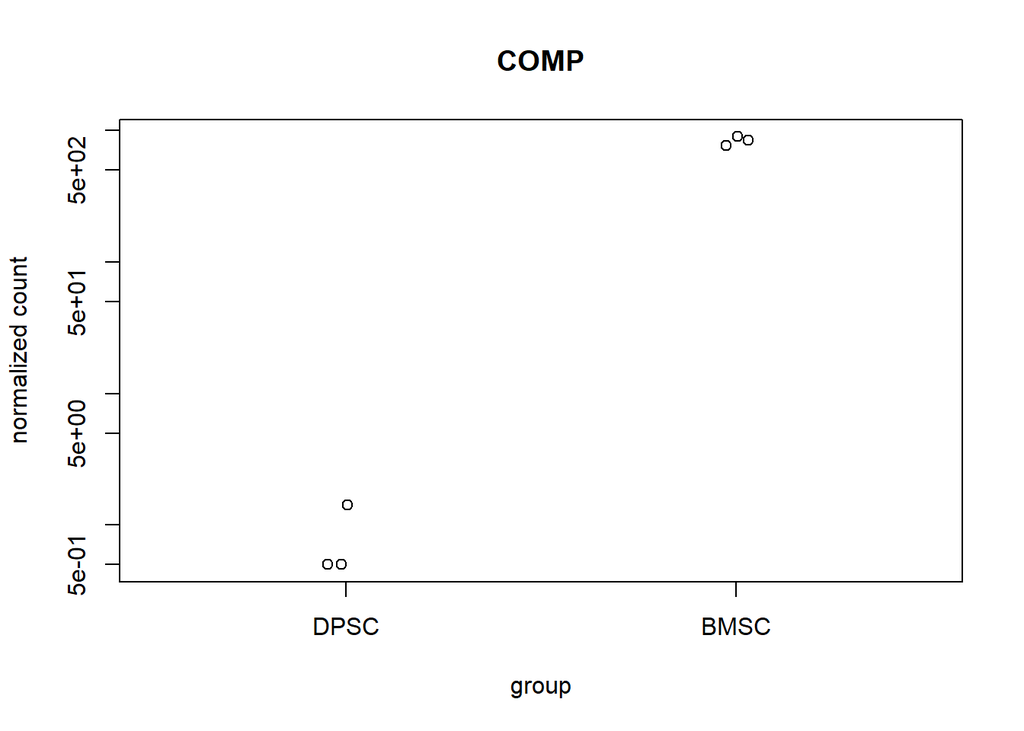

```r
plotCounts(dds, "COMP", "condition", main = "COMP")
```

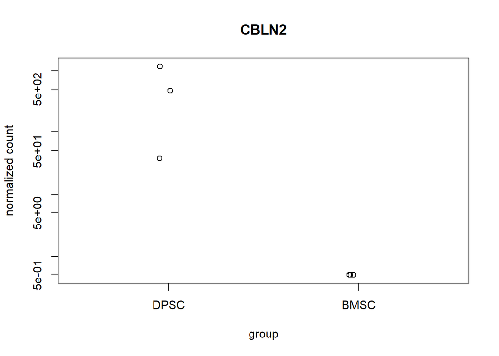

```r
plotCounts(dds, "CBLN2", "condition", main = "CBLN2")
```

This plots is a visual representation of what was already observed in the table above: LHX8 is upregulated LHX8 (LIM/homeobox protein Lhx8) is a transcription factor involved in differentiation of certain neurons and mesenchymal cells [https://www.uniprot.org/uniprot/Q68G74]. LHX8 is downregulated in Bone marrow mesenchymal stem cell. GO molecular function –> DNA-binding transcription factor activity, RNA polymerase II-specific.

CBLN2 gene May play role in synaptogenesis induction https://www.uniprot.org/uniprot/Q8IUK8#function

COMP-Ang1 complex prevents neurovascular degeneration in a murine model of diabetic retinopathy https://www.ncbi.nlm.nih.gov/pmc/articles/PMC4657578/

```r
# Which gene has the highest fold change in BMSC?
head(res[ order(res$log2FoldChange, decreasing = T), ], 10)
```

```
## log2 fold change (MAP): condition BMSC vs DPSC
## Wald test p-value: condition BMSC vs DPSC
## DataFrame with 10 rows and 5 columns
##                    baseMean   log2FoldChange            lfcSE
##                   <numeric>        <numeric>        <numeric>
## AC015987.2 684.380071508806  14.359187566354 3.32089468364039
## CHI3L1     5161.94634109604 13.4682872839495 2.15798048792833
## AC009469.1 318.882305627924 13.1360268814871 3.20207429033071
## AC119673.1 259.418784241152 12.7605983403552 3.22203681840478
## EMX2       204.317782803743 12.3446427711648 3.21945183194609
## HOXA11     192.602758991879  12.318038744185 3.14276434354139
## EGFLAM     179.526785465006 12.2312767092755 3.10723296898613
## HOXA5      156.906180057547 12.0093366866757 3.08672125234095
## HOXA7      142.240834700206 11.8742558854058 3.03682289475161
## HOXA10     621.797303297237 11.7088925889543 1.32007082839298
##                          pvalue                 padj
##                       <numeric>            <numeric>
## AC015987.2 8.55525550777496e-23 1.13263863895415e-20
## CHI3L1     2.47148355511002e-11 7.63471621725918e-10
## AC009469.1 1.05665805963627e-19 9.89661442238057e-18
## AC119673.1 1.44812616211932e-16 9.27222016821711e-15
## EMX2       1.32348891227746e-14 6.45539965855446e-13
## HOXA11     4.28762763846451e-17 2.87059115810202e-15
## EGFLAM     3.46604168070879e-18 2.73677407685741e-16
## HOXA5      1.57267501889983e-17 1.13027190746075e-15
## HOXA7       1.0601941718036e-18  9.1062921839599e-17
## HOXA10     1.74593372403919e-23 2.51986893548213e-21
```

Note that, p values can be assigned NA if (1) all counts for that gene were zero or if (2) the gene was excluded from analysis because it contained an extreme count outlier. For more information, see the outlier detection section of the advanced vignette.

### Plot of the gene with highest fold change in BMSC (lowest in DPSC)

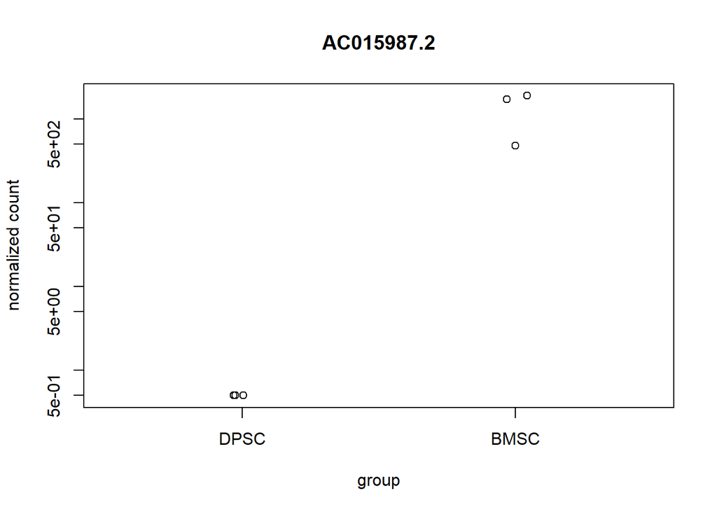

```r
plotCounts(dds, "AC015987.2", "condition", main="AC015987.2")
```

```r
resSig <- subset(res, abs(log2FoldChange) > 1) # create a subset data
head(resSig)
```

```
## log2 fold change (MAP): condition BMSC vs DPSC
## Wald test p-value: condition BMSC vs DPSC
## DataFrame with 6 rows and 5 columns
##                       baseMean    log2FoldChange             lfcSE
##                      <numeric>         <numeric>         <numeric>
## RP11-34P13.13 75.0336599397327 -1.35033951800654 0.540999099012301
## AP006222.2    33.0086433796574  1.86539024231974 0.469519092074496
## RP4-669L17.8  43.6995243322088 -1.57068746545885 0.511952750517543
## RP11-206L10.5 23.2855527325648 -1.80116239651906 0.810540992259251
## FAM87B        22.5666003094144  1.66055421828783  1.20127853550178
## LINC01128     286.729194653672  1.41987216459776 0.469124404414526
##                             pvalue                padj
##                          <numeric>           <numeric>
## RP11-34P13.13  0.00299129676342054   0.012808914711961
## AP006222.2    1.17864711914295e-05 0.00011193968971882
## RP4-669L17.8  0.000435272615485573 0.00254036467135233
## RP11-206L10.5  0.00344481225639226  0.0143681467364765
## FAM87B          0.0156988341945024  0.0506736873294936
## LINC01128     0.000587165057143463 0.00327073784441066
```

### Let us order results by adjusted p-value

```r
res <- res[order(res$padj), ]
## Merge with normalized count data
resdata <- merge(as.data.frame(res), as.data.frame(counts(dds,normalized=TRUE)), by="row.names", sort=FALSE)
names(resdata)[1] <- "Gene_id"
```

I would like to compare my list of differentially expressed genes with those found by the authors of paper publised by Shen WC et al. Let us import the list of differentially expressed genes as found by Shen WC et al, nat.comm, 2019. [https://static-content.springer.com/esm/art%3A10.1038%2Fs41467-019-10197-x/MediaObjects/41467_2019_10197_MOESM5_ESM.xlsx]

```r
library(dplyr)
paper <- readxl::read_xlsx(path= "C:/Users/Virology Tohoku/Documents/jobs/Rhoto/Internship assignement/41467_2019_10197_MOESM5_ESM.xlsx",
                           sheet = 1)
paper <- paper %>% dplyr::select("Gene", "Log2 Fold Change","PValue", "FDR")
```

Let’s save our table of genes for future use.

```r
submitt <- resdata %>% dplyr::select(Gene_id, log2FoldChange, pvalue, padj) %>% arrange(padj) %>%
  filter(abs(log2FoldChange)>1 & padj <0.05)
str(submitt)
```

```
## 'data.frame':    3136 obs. of  4 variables:
##  $ Gene_id       : 'AsIs' chr  "NEK7" "CRIP2" "IFI6" "HERC6" ...
##  $ log2FoldChange: num  2.72 6.11 -6.87 -5.81 3.21 ...
##  $ pvalue        : num  6.69e-155 2.17e-153 2.71e-98 1.74e-96 3.82e-79 ...
##  $ padj          : num  1.18e-150 1.91e-149 1.59e-94 7.68e-93 1.35e-75 ...
```

```r
write.table(submitt,"list_of_DE_genes.txt",sep="\t", row.names = F)
```

Below let us display the top 10 differnetially expressed genes that i found and those found by Shen WC et al.

```r
pander::pander(head (submitt, 10))
```

| Gene_id | log2FoldChange | pvalue | padj |
| --- | --- | --- | --- |
| NEK7 | 2.72 | 6.695e-155 | 1.179e-150 |
| CRIP2 | 6.112 | 2.173e-153 | 1.913e-149 |
| IFI6 | -6.872 | 2.708e-98 | 1.589e-94 |
| HERC6 | -5.813 | 1.745e-96 | 7.68e-93 |
| CXXC5 | 3.215 | 3.823e-79 | 1.346e-75 |
| FHL2 | 2.586 | 3.374e-78 | 9.903e-75 |
| KLF2 | 3.963 | 8.242e-72 | 2.073e-68 |
| FGF14 | 2.978 | 3.507e-68 | 7.72e-65 |
| SEMA7A | 5.557 | 8.491e-64 | 1.661e-60 |
| AK4 | 6.184 | 7.929e-61 | 1.396e-57 |

```r
pander::pander(head(paper, 10))
```

| Gene | Log2 Fold Change | PValue | FDR |
| --- | --- | --- | --- |
| FOXF1 | -12.74 | 8.161e-95 | 1.04e-90 |
| TFAP2C | -10.64 | 3.626e-91 | 2.31e-87 |
| FAM65C | -9.821 | 3.62e-81 | 1.538e-77 |
| FENDRR | -12.71 | 9.196e-76 | 2.929e-72 |
| CRIP2 | 6.07 | 4.08e-67 | 1.04e-63 |
| HOXC10 | 10.77 | 4.299e-61 | 9.13e-58 |
| COMP | 11.1 | 1.365e-56 | 2.484e-53 |
| HERC6 | -5.874 | 2.365e-52 | 3.69e-49 |
| IFI6 | -7.039 | 2.606e-52 | 3.69e-49 |
| F10 | -8.325 | 6.559e-52 | 8.358e-49 |

In order to select gene candidates for validation, et us let us rank the top 30 DE genes by their +ve and -ve fold change.

```r
pander::pander(submitt %>% dplyr::arrange(log2FoldChange) %>% head(30))
```

| Gene_id | log2FoldChange | pvalue | padj |
| --- | --- | --- | --- |
| LHX8 | -13.69 | 8.522e-22 | 1.014e-19 |
| FENDRR | -12.92 | 4.299e-53 | 5.407e-50 |
| FOXF1 | -12.92 | 4.02e-49 | 3.54e-46 |
| RP11-510C10.3 | -12.83 | 7.213e-19 | 6.351e-17 |
| CBLN2 | -12.03 | 1.517e-07 | 2.301e-06 |
| AC018470.4 | -11.82 | 1.497e-15 | 8.34e-14 |
| EDNRB | -11.46 | 2.2e-14 | 1.033e-12 |
| SP9 | -11.15 | 1.604e-13 | 6.691e-12 |
| ABCB1 | -11.13 | 1.102e-11 | 3.578e-10 |
| CTD-2541J13.2 | -11.1 | 3.546e-11 | 1.076e-09 |
| FAM65C | -10.92 | 6.974e-35 | 2.856e-32 |
| CMPK2 | -10.69 | 5.868e-22 | 7.175e-20 |
| TFAP2C | -10.43 | 1.448e-49 | 1.416e-46 |
| RP11-510C10.2 | -9.987 | 5.032e-11 | 1.477e-09 |
| WNT2 | -9.943 | 1.01e-15 | 5.852e-14 |
| PCBP3 | -9.908 | 2.327e-16 | 1.453e-14 |
| BMP5 | -9.897 | 4.98e-08 | 8.383e-07 |
| PAX3 | -9.811 | 5.318e-15 | 2.722e-13 |
| DIO3OS | -9.713 | 3.722e-07 | 5.201e-06 |
| APCDD1 | -9.474 | 1.836e-36 | 8.081e-34 |
| MX1 | -9.435 | 2.054e-49 | 1.903e-46 |
| EFCC1 | -9.417 | 7.805e-08 | 1.265e-06 |
| GBP4 | -9.369 | 6.276e-18 | 4.826e-16 |
| LGALS9 | -9.265 | 3.553e-10 | 9.107e-09 |
| CPXM1 | -8.851 | 1.292e-26 | 2.528e-24 |
| CLEC2B | -8.831 | 6.152e-10 | 1.505e-08 |
| CTD-2207O23.3 | -8.809 | 2.843e-09 | 6.135e-08 |
| MASP1 | -8.753 | 7.278e-46 | 5.339e-43 |
| F10 | -8.725 | 2.95e-45 | 1.998e-42 |
| LPAR3 | -8.715 | 9.387e-10 | 2.225e-08 |

```r
pander::pander(submitt %>% dplyr::arrange(log2FoldChange) %>% tail(30))
```

|  | Gene_id | log2FoldChange | pvalue | padj |
| --- | --- | --- | --- | --- |
| **3107** | EMX2OS | 10.35 | 1.847e-10 | 4.98e-09 |
| **3108** | MDFI | 10.35 | 9.831e-11 | 2.783e-09 |
| **3109** | FAM21D | 10.46 | 3.867e-13 | 1.523e-11 |
| **3110** | HOXA10-AS | 10.55 | 2.263e-13 | 9.218e-12 |
| **3111** | HOXA-AS2 | 10.64 | 1.345e-12 | 4.976e-11 |
| **3112** | HOXA3 | 10.66 | 1.95e-14 | 9.306e-13 |
| **3113** | HOTAIRM1 | 10.67 | 5.403e-15 | 2.757e-13 |
| **3114** | HOXC10 | 10.78 | 7.827e-25 | 1.313e-22 |
| **3115** | LINC01139 | 10.78 | 1.83e-15 | 1.01e-13 |
| **3116** | HOXC11 | 10.79 | 1.08e-14 | 5.342e-13 |
| **3117** | PRR15 | 10.8 | 1.35e-09 | 3.084e-08 |
| **3118** | GATA6 | 10.84 | 6.225e-20 | 5.925e-18 |
| **3119** | HOXC4_2 | 10.85 | 1.394e-15 | 7.845e-14 |
| **3120** | HOXB7 | 10.97 | 1.557e-05 | 0.0001429 |
| **3121** | COMP | 11.12 | 2.499e-21 | 2.821e-19 |
| **3122** | HOXC6 | 11.12 | 6.053e-21 | 6.459e-19 |
| **3123** | RP11-94A24.1 | 11.14 | 6.876e-15 | 3.469e-13 |
| **3124** | HOXA9 | 11.5 | 9.53e-23 | 1.243e-20 |
| **3125** | AC114546.1 | 11.64 | 2.236e-15 | 1.208e-13 |
| **3126** | HOXC4_1 | 11.7 | 2.369e-18 | 1.949e-16 |
| **3127** | HOXA10 | 11.71 | 1.746e-23 | 2.52e-21 |
| **3128** | HOXA7 | 11.87 | 1.06e-18 | 9.106e-17 |
| **3129** | HOXA5 | 12.01 | 1.573e-17 | 1.13e-15 |
| **3130** | EGFLAM | 12.23 | 3.466e-18 | 2.737e-16 |
| **3131** | HOXA11 | 12.32 | 4.288e-17 | 2.871e-15 |
| **3132** | EMX2 | 12.34 | 1.323e-14 | 6.455e-13 |
| **3133** | AC119673.1 | 12.76 | 1.448e-16 | 9.272e-15 |
| **3134** | AC009469.1 | 13.14 | 1.057e-19 | 9.897e-18 |
| **3135** | CHI3L1 | 13.47 | 2.471e-11 | 7.635e-10 |
| **3136** | AC015987.2 | 14.36 | 8.555e-23 | 1.133e-20 |

## d- Venn Diagram to compare our list of DE genes and the list of DE genes published in the paper

```r
library(VennDiagram)

venn.diagram(x = list("Shen WC et al,2019"=paper$Gene, "my results"=submitt$Gene_id),
             filename = "Venn_DEgenes.tiff",
             fill = c('purple', 'green'))
```

```
## [1] 1
```

[figure not shown]

venn diagram

2171 genes which i found to be differentially expessed coincide with those found by [Shen WC et al, 2019](https://www.nature.com/articles/s41467-019-10197-x).

# Conclusion

Although the method that i used and the method used in the paper of Shen WC et al. were somehow different, there is a high number of **overalpping** differentially expressed genes is **2171 (out of 3064)**.

The functional analysis and gene ontology of these differentially expressed(DE) genes can be further done using other bioinformatic tools such as GSEA, REVIGO, GORILLA, DAVID, IPA etc..

As mentionned in the instructions of this assignement, those DE genes are only related to each type of cells (we do not know wether these genes induce stem cels differenciation).